# prova_final_Q_3_last

```
                    Programa de Pos graduação em Computação Aplicada – PPCA (UnB)
```

### Nome: Nicola Defonte | Matrıcula: 231108829

```
                           ### Prova final de AEDI - Questão 3 ###
```

A questão 3 ira se basear na aplicação pratica de um problema de ANOVA. Esses problemas são originados de dados reais aplicados em problemas de Neǵocios. A questão ira abordar a aplicação do problema Vendas de Varejo on-line. Esse problema trata-se do objetivo de as medias de quantidades e preços dos produtos agrupados por paıses. Com esses dados pede-se:

a) Elaborar uma analise descritiva da base de dados, analise grafica e por tabelas. (10%)  
b) Realize a comparação entre a quantidade e o preço agrupados por paıses (Use ANOVA). (40%)  
c) Corrigir os problemas dos pressupostos da ANOVA e gerar o modelo mais ajustado para os dados. (40%)  
d) Interpretar os resultados e evidenciar as principais tomadas de decis ̃oes possıveis com os resultados encontrados. (10%)

```
                                    ### desenvolvimento ###
```

### Requisitos da ANOVA:

*Normalidade*: Os resíduos entre os valores observados e os valores previstos pelo modelo ANOVA devem seguir uma distribuição normal dentro de cada grupo.

*Independência*: As observações dentro de cada grupo e entre os grupos são consideradas independentes. Em outras palavras, os valores de um grupo não devem ser influenciados ou relacionados aos valores de outro grupo.

*Homogeneidade da Variância (Homoscedasticidade)*: A variabilidade (variância) da variável dependente deve ser aproximadamente igual em todos os níveis da variável independente categórica. Em outras palavras, a distribuição dos pontos de dados deve ser semelhante entre os diferentes grupos.

## Objetivo e Hipotese da ANOVA

Hipótese nula (H0): Não existem diferenças significativas nas médias de preços e quantidades entre os grupos (países).

Hipótese alternativa (H1): Pelo menos um grupo (país) difere significativamente dos demais em termos de médias de preços e quantidades.

A hipótese nula assume que não há variações significativas nos preços e quantidades entre os diferentes países. A hipótese alternativa, por sua vez, propõe que pelo menos um país apresenta uma diferença estatisticamente significativa nas médias de preços e quantidades em comparação com os outros países.

### Método

Nesta análise, foram carregados e explorados os conjuntos de dados correspondentes aos anos 2009-2010 e 2010-2011. O objetivo foi comparar a quantidade e o preço de produtos agrupados por país, utilizando a técnica estatística de Análise de Variância (ANOVA).

Primeiramente, foram examinados os conjuntos de dados, verificando os tipos de variáveis presentes e a quantidade de frequências em cada variável. Colunas consideradas não essenciais para a análise foram removidas, visando focar nas variáveis de interesse: "Price" (preço) e "Quantity" (quantidade).

Em seguida, foi realizada a limpeza do dataset, verificando a presença de valores nulos e de valores negativos que poderiam ser atribuídos a estornos de vendas. Para garantir uma análise mais robusta, optou-se por remover países com menos de 200 registros, a fim de manter amostras representativas.

A normalidade dos dados foi avaliada por meio da análise dos gráficos Quantil-Quantil (Q-Q) e da realização dos testes de normalidade de Shapiro-Wilk para cada país, tanto para a variável "Price" quanto para a variável "Quantity". Os gráficos de boxplot também foram gerados para visualizar a distribuição dos dados por país.

Com os dados preparados e limpos, foi construída uma tabela pivot contendo as informações necessárias de preço e quantidade, organizadas por país. Isso permitiu uma visualização mais clara e organizada dos dados.

Para comparar as médias entre os grupos de países, foi aplicada a técnica estatística de ANOVA. A ANOVA avalia se existe uma diferença significativa nas médias entre os grupos, considerando a variável independente (país) e a variável dependente (preço ou quantidade). Caso a ANOVA indique uma diferença significativa, o teste de Tukey foi realizado para análise de comparação múltipla, identificando quais grupos diferem significativamente entre si.

A normalidade dos resíduos gerados pela ANOVA foi avaliada pelos testes de Shapiro-Wilk e Kolmogorov-Smirnov, complementados pelos gráficos Q-Q. Além disso, foi aplicado o teste global de Levene para investigar a hipótese de homogeneidade de variâncias (homocedasticidade) entre os grupos.

Uma abordagem alternativa foi utilizada. O teste não paramétrico de Kruskall-Wallis foi empregado para comparar as medianas entre os grupos.

Por fim, com base nos resultados obtidos, foram elaboradas as conclusões finais e gerais, destacando as diferenças significativas encontradas nas médias ou medianas das variáveis analisadas, bem como outras observações relevantes para o estudo em questão.

#### Bibliotecas

```python
import pandas as pd
import yfinance as yf
import numpy as np
import math
import matplotlib.pyplot as plt
import plotly.express as px
import seaborn as sns
from scipy import stats
import statistics as stat
from scipy import optimize
import statsmodels.api as sm
from statsmodels.formula.api import ols
from bioinfokit.analys import stat
from scipy.stats import tukey_hsd
from scipy.stats import mannwhitneyu
from scipy.stats import wilcoxon
from scipy.stats import kruskal
import requests
from scipy.stats import f_oneway
from statsmodels.stats.multicomp import pairwise_tukeyhsd
```

### Leitura dos Dados

```python
# Load the first CSV file into a dataframe
df1 = pd.read_csv('Year 2009-2010.csv', sep = ',', encoding='latin-1')

# Load the second CSV file into another dataframe
df2 = pd.read_csv('Year 2010-2011.csv', sep = ',', encoding='latin-1')

# Concatenate the two dataframes vertically
data = pd.concat([df1, df2], axis=0)

# Reset the index of the combined dataframe
data = data.reset_index(drop=True)

print(data.shape)
print(list(data.columns))
```

```
(1067371, 8)
['Invoice', 'StockCode', 'Description', 'Quantity', 'InvoiceDate', 'Price', 'Customer ID', 'Country']
```

```python
data
```

|  | Invoice | StockCode | Description | Quantity | InvoiceDate | Price | Customer ID | Country |
| --- | --- | --- | --- | --- | --- | --- | --- | --- |
| 0 | 489434 | 85048 | 15CM CHRISTMAS GLASS BALL 20 LIGHTS | 12 | 12/1/2009 7:45 | 6.95 | 13085.0 | United Kingdom |
| 1 | 489434 | 79323P | PINK CHERRY LIGHTS | 12 | 12/1/2009 7:45 | 6.75 | 13085.0 | United Kingdom |
| 2 | 489434 | 79323W | WHITE CHERRY LIGHTS | 12 | 12/1/2009 7:45 | 6.75 | 13085.0 | United Kingdom |
| 3 | 489434 | 22041 | RECORD FRAME 7" SINGLE SIZE | 48 | 12/1/2009 7:45 | 2.10 | 13085.0 | United Kingdom |
| 4 | 489434 | 21232 | STRAWBERRY CERAMIC TRINKET BOX | 24 | 12/1/2009 7:45 | 1.25 | 13085.0 | United Kingdom |
| ... | ... | ... | ... | ... | ... | ... | ... | ... |
| 1067366 | 581587 | 22899 | CHILDREN'S APRON DOLLY GIRL | 6 | 12/9/2011 12:50 | 2.10 | 12680.0 | France |
| 1067367 | 581587 | 23254 | CHILDRENS CUTLERY DOLLY GIRL | 4 | 12/9/2011 12:50 | 4.15 | 12680.0 | France |
| 1067368 | 581587 | 23255 | CHILDRENS CUTLERY CIRCUS PARADE | 4 | 12/9/2011 12:50 | 4.15 | 12680.0 | France |
| 1067369 | 581587 | 22138 | BAKING SET 9 PIECE RETROSPOT | 3 | 12/9/2011 12:50 | 4.95 | 12680.0 | France |
| 1067370 | 581587 | POST | POSTAGE | 1 | 12/9/2011 12:50 | 18.00 | 12680.0 | France |

1067371 rows × 8 columns

```python
#Procurando colunas com valores Nan

data.isnull().sum(axis = 0)
```

```
Invoice             0
StockCode           0
Description      4382
Quantity            0
InvoiceDate         0
Price               0
Customer ID    243007
Country             0
dtype: int64
```

```python
# Filtrando as colunas

data = data.filter(['Quantity','Price','Country'])
```

```python
# Mostrando os dados unicos

data_uni = pd.concat([d.reset_index(drop=False) for d in [data.nunique(), data.dtypes]], axis=1)
data_uni = data_uni.transpose()
data_uni = data_uni.drop_duplicates().transpose()
data_uni.columns = ['variaveis','unique','dtype']
data_uni
```

|  | variaveis | unique | dtype |
| --- | --- | --- | --- |
| 0 | Quantity | 1057 | int64 |
| 1 | Price | 2807 | float64 |
| 2 | Country | 43 | object |

```python
# Mostrando os paises

print('Countries')
countries = data['Country'].unique()
print(countries)
```

```
Countries
['United Kingdom' 'France' 'USA' 'Belgium' 'Australia' 'EIRE' 'Germany'
 'Portugal' 'Japan' 'Denmark' 'Nigeria' 'Netherlands' 'Poland' 'Spain'
 'Channel Islands' 'Italy' 'Cyprus' 'Greece' 'Norway' 'Austria' 'Sweden'
 'United Arab Emirates' 'Finland' 'Switzerland' 'Unspecified' 'Malta'
 'Bahrain' 'RSA' 'Bermuda' 'Hong Kong' 'Singapore' 'Thailand' 'Israel'
 'Lithuania' 'West Indies' 'Lebanon' 'Korea' 'Brazil' 'Canada' 'Iceland'
 'Saudi Arabia' 'Czech Republic' 'European Community']
```

```python
# Check for negative values in the 'Values' column
has_negative = (data['Quantity'] <= 0).sum()

if has_negative:
    print("DataFrame contains negative values.")
else:
    print("DataFrame does not contain negative values.")
has_negative
```

```
DataFrame contains negative values.
```

```
22950
```

```python
# Check for negative values in the 'Values' column
has_negative = (data['Price'] <= 0).sum()

if has_negative:
    print("DataFrame contains negative values.")
else:
    print("DataFrame does not contain negative values.")
has_negative
```

```
DataFrame contains negative values.
```

```
6207
```

```python
# Drop rows where 'Values' column is <= 0

data = data[~(data['Price'] <= 0)]

data = data[~(data['Quantity'] <= 0)]

data = data.reset_index(drop=True)
data.shape
```

```
(1041671, 3)
```

```python
# Eliminando paises com poucas frequencias, min 200

counts = data["Country"].value_counts()
data = data.loc[data["Country"].isin(counts.index[counts > 200])]
data = data.reset_index(drop=True)
```

```python
# Drop rows where 'Country' column contains 'Unspecified'
data = data[~data['Country'].str.contains('Unspecified')]
data = data.reset_index(drop=True)
```

```python
#Frequencies of Countries
data["Country"].value_counts()
```

```
United Kingdom          958502
EIRE                     17349
Germany                  16694
France                   13940
Netherlands               5088
Spain                     3719
Switzerland               3136
Belgium                   3068
Portugal                  2562
Australia                 1812
Channel Islands           1569
Italy                     1468
Norway                    1436
Sweden                    1338
Cyprus                    1155
Finland                   1032
Austria                    922
Denmark                    798
Greece                     657
Poland                     512
Japan                      485
United Arab Emirates       467
USA                        409
Israel                     369
Hong Kong                  358
Singapore                  339
Malta                      282
Iceland                    253
Canada                     228
Name: Country, dtype: int64
```

```python
# Check for infinite values
has_infinite_pri = np.isinf(data['Price']).any()
has_nan_pri = np.isnan(data['Price']).any()

if has_infinite_pri or has_nan_pri:
    print("Price contains infinite values.", has_infinite_pri, has_nan_pri )
else:
    print("Price does not contain infinite values.")

has_infinite_qua = np.isinf(data['Price']).any()
has_nan_qua = np.isnan(data['Price']).any()

if has_infinite_qua or has_nan_qua:
    print("Quantity contains infinite values.",has_infinite_qua, has_nan_qua )
else:
    print("Quantity does not contain infinite values.")
```

```
Price does not contain infinite values.
Quantity does not contain infinite values.
```

### Tratamento e Descrição dos Dados

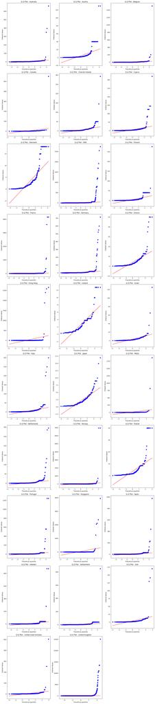

```python
# Group the data by country
grouped_data = data.groupby('Country')

# Get the number of unique countries
num_countries = len(grouped_data)

# Calculate the number of rows and columns in the grid
num_rows = (num_countries + 2) // 3
num_cols = min(num_countries, 3)

# Create a grid of subplots for Q-Q plots
fig, axes = plt.subplots(nrows=num_rows, ncols=num_cols, figsize=(16, 72))

# Flatten the axes array for easy iteration
axes = axes.flatten()

# Iterate over each country and populate the subplots with Q-Q plots
for i, (country, group) in enumerate(grouped_data):
    ax = axes[i]
    stats.probplot(group['Price'], plot=ax)
    ax.set_title(f'Q-Q Plot - {country}')

# Remove any empty subplots
if num_countries < len(axes):
    for i in range(num_countries, len(axes)):
        fig.delaxes(axes[i])

# Adjust the layout of the subplots
plt.tight_layout()

# Show the plot
plt.show()
```

```python
from scipy.stats import shapiro

# Separate the data by country
country_groups = data.groupby('Country')

show_shapiro_price = []

# Iterate over each country group
for country, group_data in country_groups:
    variable_data = group_data['Price']

    # Perform Shapiro-Wilk test for normality
    _, p_value = shapiro(variable_data)

    print(f"Shapiro-Wilk test Price for {country}: p-value = {p_value}")
    if p_value > 0.05:
        show_shapiro_price.append(country)
print('-----'*10)
print(show_shapiro_price, str(len(show_shapiro_price)) + ' / ' + str(len(country_groups)))
```

```
Shapiro-Wilk test Price for Australia: p-value = 0.0
Shapiro-Wilk test Price for Austria: p-value = 0.0
Shapiro-Wilk test Price for Belgium: p-value = 0.0
Shapiro-Wilk test Price for Canada: p-value = 5.836375883859515e-32
Shapiro-Wilk test Price for Channel Islands: p-value = 0.0
Shapiro-Wilk test Price for Cyprus: p-value = 0.0
Shapiro-Wilk test Price for Denmark: p-value = 1.3294596093566181e-37
Shapiro-Wilk test Price for EIRE: p-value = 0.0
Shapiro-Wilk test Price for Finland: p-value = 0.0
Shapiro-Wilk test Price for France: p-value = 0.0
Shapiro-Wilk test Price for Germany: p-value = 0.0
Shapiro-Wilk test Price for Greece: p-value = 5.544208227093081e-38
Shapiro-Wilk test Price for Hong Kong: p-value = 5.088319313539202e-38
Shapiro-Wilk test Price for Iceland: p-value = 5.443231001632228e-19
Shapiro-Wilk test Price for Israel: p-value = 1.5270146578888207e-35
Shapiro-Wilk test Price for Italy: p-value = 0.0
Shapiro-Wilk test Price for Japan: p-value = 1.0107650126693536e-26
Shapiro-Wilk test Price for Malta: p-value = 7.67821143534173e-35
Shapiro-Wilk test Price for Netherlands: p-value = 0.0
Shapiro-Wilk test Price for Norway: p-value = 0.0
Shapiro-Wilk test Price for Poland: p-value = 1.793054915610384e-35
Shapiro-Wilk test Price for Portugal: p-value = 0.0
Shapiro-Wilk test Price for Singapore: p-value = 5.155177953765191e-37
Shapiro-Wilk test Price for Spain: p-value = 0.0
Shapiro-Wilk test Price for Sweden: p-value = 0.0
Shapiro-Wilk test Price for Switzerland: p-value = 0.0
Shapiro-Wilk test Price for USA: p-value = 4.0824588680560626e-39
Shapiro-Wilk test Price for United Arab Emirates: p-value = 2.4564762079614043e-42
```

```
Shapiro-Wilk test Price for United Kingdom: p-value = 0.0
--------------------------------------------------
[] 0 / 29
```

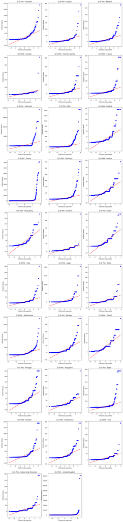

```python
# Get the number of unique countries
num_countries = len(grouped_data)

# Calculate the number of rows and columns in the grid
num_rows = (num_countries + 2) // 3
num_cols = min(num_countries, 3)

# Create a grid of subplots for Q-Q plots
fig, axes = plt.subplots(nrows=num_rows, ncols=num_cols, figsize=(16, 72))

# Flatten the axes array for easy iteration
axes = axes.flatten()

# Iterate over each country and populate the subplots with Q-Q plots
for i, (country, group) in enumerate(grouped_data):
    ax = axes[i]
    stats.probplot(group['Quantity'], plot=ax)
    ax.set_title(f'Q-Q Plot - {country}')

# Remove any empty subplots
if num_countries < len(axes):
    for i in range(num_countries, len(axes)):
        fig.delaxes(axes[i])

# Adjust the layout of the subplots
# plt.tight_layout()

# Show the plot
plt.show()
```

```python
from scipy.stats import shapiro

# Separate the data by country
country_groups = data.groupby('Country')

show_shapiro_quant = []

# Iterate over each country group
for country, group_data in country_groups:
    variable_data = group_data['Quantity']

    # Perform Shapiro-Wilk test for normality
    _, p_value = shapiro(variable_data)

    print(f"Shapiro-Wilk test Quantity for {country}: p-value = {p_value}")
    if p_value > 0.05:
        show_shapiro_quant.append(country)
print('-----'*10)
print(show_shapiro_quant, str(len(show_shapiro_quant)) + ' / ' + str(len(country_groups)))
```

```
Shapiro-Wilk test Quantity for Australia: p-value = 0.0
Shapiro-Wilk test Quantity for Austria: p-value = 0.0
Shapiro-Wilk test Quantity for Belgium: p-value = 0.0
Shapiro-Wilk test Quantity for Canada: p-value = 4.972226375729636e-30
Shapiro-Wilk test Quantity for Channel Islands: p-value = 0.0
Shapiro-Wilk test Quantity for Cyprus: p-value = 0.0
Shapiro-Wilk test Quantity for Denmark: p-value = 0.0
Shapiro-Wilk test Quantity for EIRE: p-value = 0.0
Shapiro-Wilk test Quantity for Finland: p-value = 2.802596928649634e-45
Shapiro-Wilk test Quantity for France: p-value = 0.0
Shapiro-Wilk test Quantity for Germany: p-value = 0.0
Shapiro-Wilk test Quantity for Greece: p-value = 3.152805999639898e-30
Shapiro-Wilk test Quantity for Hong Kong: p-value = 1.370419025311257e-24
Shapiro-Wilk test Quantity for Iceland: p-value = 9.532393269010162e-29
Shapiro-Wilk test Quantity for Israel: p-value = 5.743005334978958e-22
Shapiro-Wilk test Quantity for Italy: p-value = 0.0
Shapiro-Wilk test Quantity for Japan: p-value = 5.868152558804292e-38
Shapiro-Wilk test Quantity for Malta: p-value = 8.362741708156659e-29
Shapiro-Wilk test Quantity for Netherlands: p-value = 0.0
Shapiro-Wilk test Quantity for Norway: p-value = 0.0
Shapiro-Wilk test Quantity for Poland: p-value = 1.807467688326328e-25
Shapiro-Wilk test Quantity for Portugal: p-value = 0.0
Shapiro-Wilk test Quantity for Singapore: p-value = 7.894539375694875e-27
Shapiro-Wilk test Quantity for Spain: p-value = 0.0
Shapiro-Wilk test Quantity for Sweden: p-value = 0.0
Shapiro-Wilk test Quantity for Switzerland: p-value = 0.0
Shapiro-Wilk test Quantity for USA: p-value = 1.686331869595006e-33
Shapiro-Wilk test Quantity for United Arab Emirates: p-value = 3.7583996074500015e-36
Shapiro-Wilk test Quantity for United Kingdom: p-value = 0.0
--------------------------------------------------
[] 0 / 29
```

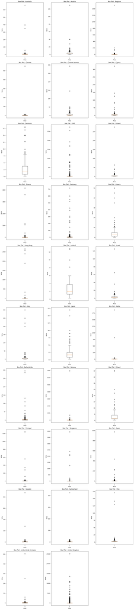

```python
# Plotando os Boxplots para os preços

# Get the number of unique countries
num_countries = len(grouped_data)

# Calculate the number of rows and columns in the grid
num_rows = (num_countries + 2) // 3
num_cols = min(num_countries, 3)

# Create a grid of subplots
fig, axes = plt.subplots(nrows=num_rows, ncols=num_cols, figsize=(16, 72))

# Flatten the axes array for easy iteration
axes = axes.flatten()

# Iterate over each country and populate the subplots with box plots
for i, (country, group) in enumerate(grouped_data):
    ax = axes[i]
    ax.boxplot(group['Price'])
    ax.set_xlabel('Price')
    ax.set_ylabel('Value')
    ax.set_title(f'Box Plot - {country}')

# Remove any empty subplots
if num_countries < len(axes):
    for i in range(num_countries, len(axes)):
        fig.delaxes(axes[i])

# Adjust the layout of the subplots
plt.tight_layout()

# Show the plot
plt.show()
```

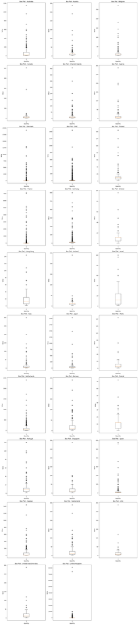

```python
# Plotando os Boxplots para as quantidades

# Get the number of unique countries
num_countries = len(grouped_data)

# Calculate the number of rows and columns in the grid
num_rows = (num_countries + 2) // 3
num_cols = min(num_countries, 3)

# Create a grid of subplots
fig, axes = plt.subplots(nrows=num_rows, ncols=num_cols, figsize=(16, 72))

# Flatten the axes array for easy iteration
axes = axes.flatten()

# Iterate over each country and populate the subplots with box plots
for i, (country, group) in enumerate(grouped_data):
    ax = axes[i]
    ax.boxplot(group['Quantity'])
    ax.set_xlabel('Quantity')
    ax.set_ylabel('Value')
    ax.set_title(f'Box Plot - {country}')

# Remove any empty subplots
if num_countries < len(axes):
    for i in range(num_countries, len(axes)):
        fig.delaxes(axes[i])

# Adjust the layout of the subplots
plt.tight_layout()

# Show the plot
plt.show()
```

```python
# Calcule as médias agrupadas por país
medias_paises = data.groupby('Country').mean()
medias_paises = medias_paises.reset_index(drop=True)
medias_paises
```

|  | Quantity | Price |
| --- | --- | --- |
| 0 | 57.444812 | 3.603681 |
| 1 | 12.557484 | 4.281681 |
| 2 | 11.506519 | 4.238814 |
| 3 | 16.039474 | 4.640746 |
| 4 | 13.691523 | 4.637234 |
| 5 | 9.511688 | 5.095645 |
| 6 | 298.151629 | 2.854599 |
| 7 | 19.614329 | 5.453236 |
| 8 | 13.929264 | 4.765698 |
| 9 | 19.747991 | 4.252544 |
| 10 | 13.656583 | 3.595259 |
| 11 | 11.756469 | 3.852024 |
| 12 | 19.779330 | 31.010782 |
| 13 | 12.988142 | 2.546087 |
| 14 | 15.016260 | 3.564797 |
| 15 | 10.559264 | 4.765661 |
| 16 | 68.715464 | 2.005691 |
| 17 | 8.932624 | 13.361773 |
| 18 | 75.467178 | 2.687150 |
| 19 | 18.943593 | 14.205230 |
| 20 | 11.382812 | 3.636641 |
| 21 | 11.088603 | 4.964984 |
| 22 | 20.631268 | 39.299410 |
| 23 | 13.658510 | 4.243391 |
| 24 | 66.255605 | 4.907160 |
| 25 | 16.863520 | 3.754850 |
| 26 | 12.870416 | 3.577237 |
| 27 | 15.676660 | 4.298394 |
| 28 | 9.789489 | 4.021459 |

```python
# Initialize an empty DataFrame to store the pivoted data
pivot_data = pd.DataFrame()

# Iterate over unique countries
for country in data['Country'].unique():
    # Filter the data for the current country
    country_data = data[data['Country'] == country]

    # Create a new column for the current country and fill it with the corresponding price values
    pivot_data[country +'_price'] = country_data['Price'].reset_index(drop=True)

    # Create a new column for the current country and fill it with the corresponding price values
    pivot_data[country + '_quantity'] = country_data['Quantity'].reset_index(drop=True)

pivot_melt_data = pd.melt(pivot_data).dropna().reset_index(drop=True)
```

```python
# Print the pivoted data
pivot_data
```

|  | United Kingdom_price | United Kingdom_quantity | France_price | France_quantity | USA_price | USA_quantity | Belgium_price | Belgium_quantity | Australia_price | Australia_quantity | ... | Hong Kong_price | Hong Kong_quantity | Singapore_price | Singapore_quantity | Israel_price | Israel_quantity | Canada_price | Canada_quantity | Iceland_price | Iceland_quantity |
| --- | --- | --- | --- | --- | --- | --- | --- | --- | --- | --- | --- | --- | --- | --- | --- | --- | --- | --- | --- | --- | --- |
| 0 | 6.95 | 12 | 1.45 | 12.0 | 141.00 | 1.0 | 130.00 | 1.0 | 2.95 | 12.0 | ... | 1.65 | 12.0 | 1.25 | 12.0 | 1.25 | 24.0 | 3.35 | 6.0 | 2.95 | 6.0 |
| 1 | 6.75 | 12 | 4.95 | 9.0 | 2.10 | 24.0 | 2.10 | 6.0 | 1.65 | 6.0 | ... | 1.95 | 10.0 | 1.25 | 12.0 | 1.25 | 24.0 | 0.42 | 12.0 | 2.95 | 6.0 |
| 2 | 6.75 | 12 | 4.95 | 9.0 | 0.42 | 11.0 | 0.85 | 12.0 | 4.25 | 4.0 | ... | 1.65 | 10.0 | 12.75 | 3.0 | 4.25 | 24.0 | 1.25 | 16.0 | 1.25 | 12.0 |
| 3 | 2.10 | 48 | 2.55 | 12.0 | 2.95 | 6.0 | 6.75 | 2.0 | 2.10 | 6.0 | ... | 1.65 | 12.0 | 1.25 | 12.0 | 4.25 | 24.0 | 2.55 | 6.0 | 0.85 | 24.0 |
| 4 | 1.25 | 24 | 5.95 | 3.0 | 2.95 | 6.0 | 2.10 | 12.0 | 2.95 | 12.0 | ... | 1.65 | 12.0 | 10.95 | 4.0 | 0.55 | 24.0 | 0.29 | 24.0 | 0.65 | 12.0 |
| ... | ... | ... | ... | ... | ... | ... | ... | ... | ... | ... | ... | ... | ... | ... | ... | ... | ... | ... | ... | ... | ... |
| 958497 | 1.95 | 12 | NaN | NaN | NaN | NaN | NaN | NaN | NaN | NaN | ... | NaN | NaN | NaN | NaN | NaN | NaN | NaN | NaN | NaN | NaN |
| 958498 | 2.95 | 8 | NaN | NaN | NaN | NaN | NaN | NaN | NaN | NaN | ... | NaN | NaN | NaN | NaN | NaN | NaN | NaN | NaN | NaN | NaN |
| 958499 | 1.25 | 24 | NaN | NaN | NaN | NaN | NaN | NaN | NaN | NaN | ... | NaN | NaN | NaN | NaN | NaN | NaN | NaN | NaN | NaN | NaN |
| 958500 | 8.95 | 24 | NaN | NaN | NaN | NaN | NaN | NaN | NaN | NaN | ... | NaN | NaN | NaN | NaN | NaN | NaN | NaN | NaN | NaN | NaN |
| 958501 | 7.08 | 10 | NaN | NaN | NaN | NaN | NaN | NaN | NaN | NaN | ... | NaN | NaN | NaN | NaN | NaN | NaN | NaN | NaN | NaN | NaN |

958502 rows × 58 columns

## ANOVA e Teste de Hipótese

Queremos testar as medias de grupos diferentes assumindo as seguintes condiçoes:

Para testar a diferença das médias, começamos com uma Hipótese Nula $H_0$ :  
$ H_0 = μ_1 = μ_2 = ···= μ_m$

Assumimos homocedasticidade ou seja que a variabilidade das observações em cada grupo em relação à média do grupo é a mesma para todos os grupos.  
$ σ^2_1 = σ^2_2 = · · · = σ^2_m$

A principio assumimos que os resultados dos testes retornem um modelo com distribução normal

```python
#Criando a tabela dos preços

tab_pri = pivot_data.copy()

tab_pri = tab_pri.filter(like="_price")
tab_pri = pd.melt(tab_pri).dropna().reset_index(drop=True)
tab_pri
```

|  | variable | value |
| --- | --- | --- |
| 0 | United Kingdom_price | 6.95 |
| 1 | United Kingdom_price | 6.75 |
| 2 | United Kingdom_price | 6.75 |
| 3 | United Kingdom_price | 2.10 |
| 4 | United Kingdom_price | 1.25 |
| ... | ... | ... |
| 1039942 | Iceland_price | 0.85 |
| 1039943 | Iceland_price | 1.95 |
| 1039944 | Iceland_price | 0.83 |
| 1039945 | Iceland_price | 0.42 |
| 1039946 | Iceland_price | 0.42 |

1039947 rows × 2 columns

```python
# Criando a tabela para as quantidades

tab_qua = pivot_data.copy()

tab_qua = tab_qua.filter(like="_quantity")
tab_qua = pd.melt(tab_qua).dropna().reset_index(drop=True)
tab_qua
```

|  | variable | value |
| --- | --- | --- |
| 0 | United Kingdom_quantity | 12.0 |
| 1 | United Kingdom_quantity | 12.0 |
| 2 | United Kingdom_quantity | 12.0 |
| 3 | United Kingdom_quantity | 48.0 |
| 4 | United Kingdom_quantity | 24.0 |
| ... | ... | ... |
| 1039942 | Iceland_quantity | 10.0 |
| 1039943 | Iceland_quantity | 12.0 |
| 1039944 | Iceland_quantity | 16.0 |
| 1039945 | Iceland_quantity | 20.0 |
| 1039946 | Iceland_quantity | 20.0 |

1039947 rows × 2 columns

```python
# Ordinary Least Squares (OLS) model for prices

model_pri = ols('value ~ variable', data=tab_pri).fit()
anova_table_pri = sm.stats.anova_lm(model_pri, typ=2)
anova_table_pri
```

|  | sum_sq | df | F | PR(>F) |
| --- | --- | --- | --- | --- |
| variable | 9.129033e+05 | 28.0 | 12.309824 | 3.005146e-56 |
| Residual | 2.754317e+09 | 1039918.0 | NaN | NaN |

```python
# Ordinary Least Squares (OLS) model for Quantity
model_qua = ols('value ~ variable', data=tab_qua).fit()
anova_table_qua = sm.stats.anova_lm(model_qua, typ=2)
anova_table_qua
```

|  | sum_sq | df | F | PR(>F) |
| --- | --- | --- | --- | --- |
| variable | 1.007660e+08 | 28.0 | 225.870454 | 0.0 |
| Residual | 1.656898e+10 | 1039918.0 | NaN | NaN |

Dos resultados **PR(>F)** obtidos podemos dizer de reijetar a ipotese nula por ambas as variaveis.

Para ser reijetada, pelo meno um dos grupos deveria ser significativamente diferente e de fato è assim.  
Se pode observar no test de Tukey seguinte em baixo.

### Test par a par de Tukey

```python
# Tukey Test Price

df_melt_value = tab_pri["value"]
df_melt_variable = tab_pri["variable"]

tukey = pairwise_tukeyhsd(endog=df_melt_value,
                           groups=df_melt_variable,
                           alpha=0.05)
print(tukey)
```

```
                     Multiple Comparison of Means - Tukey HSD, FWER=0.05
==============================================================================================
          group1                     group2           meandiff p-adj   lower    upper   reject
----------------------------------------------------------------------------------------------
           Australia_price              Austria_price    0.678    1.0  -7.0914   8.4474  False
           Australia_price              Belgium_price   0.6351    1.0  -5.0552   6.3255  False
           Australia_price               Canada_price   1.0371    1.0 -12.4589   14.533  False
           Australia_price      Channel Islands_price   1.0336    1.0  -5.5896   7.6567  False
           Australia_price               Cyprus_price    1.492    1.0  -5.7394   8.7234  False
           Australia_price              Denmark_price  -0.7491    1.0  -8.9088   7.4106  False
           Australia_price                 EIRE_price   1.8496 0.9998  -2.8921   6.5912  False
           Australia_price              Finland_price    1.162    1.0  -6.3279    8.652  False
           Australia_price               France_price   0.6489    1.0  -4.1473    5.445  False
           Australia_price              Germany_price  -0.0084    1.0  -4.7588    4.742  False
           Australia_price               Greece_price   0.2483    1.0  -8.4981   8.9948  False
           Australia_price            Hong Kong_price  27.4071    0.0  16.2989  38.5153   True
           Australia_price              Iceland_price  -1.0576    1.0 -13.9476  11.8325  False
           Australia_price               Israel_price  -0.0389    1.0 -11.0079  10.9302  False
           Australia_price                Italy_price    1.162    1.0  -5.5822   7.9062  False
           Australia_price                Japan_price   -1.598    1.0 -11.4169   8.2209  False
           Australia_price                Malta_price   9.7581 0.3984  -2.5366  22.0528  False
           Australia_price          Netherlands_price  -0.9165    1.0  -6.1707   4.3377  False
           Australia_price               Norway_price  10.6015    0.0    3.816  17.3871   True
           Australia_price               Poland_price    0.033    1.0  -9.5796   9.6455  False
           Australia_price             Portugal_price   1.3613    1.0   -4.534   7.2566  False
           Australia_price            Singapore_price  35.6957    0.0  24.3306  47.0609   True
           Australia_price                Spain_price   0.6397    1.0  -4.8626    6.142  False
           Australia_price               Sweden_price   1.3035    1.0  -5.6193   8.2263  False
           Australia_price          Switzerland_price   0.1512    1.0  -5.5162   5.8185  False
           Australia_price                  USA_price  -0.0264    1.0 -10.5404  10.4875  False
           Australia_price United Arab Emirates_price   0.6947    1.0  -9.2724  10.6618  False
           Australia_price       United Kingdom_price   0.4178    1.0  -4.0983   4.9339  False
             Austria_price              Belgium_price  -0.0429    1.0  -7.2561   7.1703  False
             Austria_price               Canada_price   0.3591    1.0 -13.8462  14.5643  False
             Austria_price      Channel Islands_price   0.3556    1.0  -7.6142   8.3253  False
             Austria_price               Cyprus_price    0.814    1.0   -7.668   9.2959  False
             Austria_price              Denmark_price  -1.4271    1.0 -10.7131    7.859  False
             Austria_price                 EIRE_price   1.1716    1.0  -5.3195   7.6626  False
             Austria_price              Finland_price    0.484    1.0  -8.2194   9.1875  False
             Austria_price               France_price  -0.0291    1.0  -6.5601   6.5018  False
```

[output cut: 356 more lines]

```
               Spain_price          Switzerland_price  -0.4885    1.0  -5.1448   4.1677  False
               Spain_price                  USA_price  -0.6662    1.0 -10.6714   9.3391  False
               Spain_price United Arab Emirates_price    0.055    1.0  -9.3739   9.4839  False
               Spain_price       United Kingdom_price  -0.2219    1.0  -3.3774   2.9335  False
              Sweden_price          Switzerland_price  -1.1523    1.0  -7.4237   5.1191  False
              Sweden_price                  USA_price  -1.3299    1.0 -12.1814   9.5216  False
              Sweden_price United Arab Emirates_price  -0.6088    1.0 -10.9313   9.7138  False
              Sweden_price       United Kingdom_price  -0.8857    1.0  -6.1399   4.3685  False
         Switzerland_price                  USA_price  -0.1776    1.0 -10.2746   9.9194  False
         Switzerland_price United Arab Emirates_price   0.5435    1.0  -8.9827  10.0697  False
         Switzerland_price       United Kingdom_price   0.2666    1.0  -3.1686   3.7018  False
                 USA_price United Arab Emirates_price   0.7212    1.0 -12.2855  13.7278  False
                 USA_price       United Kingdom_price   0.4442    1.0  -9.0545   9.9429  False
United Arab Emirates_price       United Kingdom_price  -0.2769    1.0  -9.1665   8.6126  False
----------------------------------------------------------------------------------------------
```

```python
# Tukey Test for Quantity

df_melt_value = tab_qua["value"]
df_melt_variable = tab_qua["variable"]

tukey = pairwise_tukeyhsd(endog=df_melt_value,
                           groups=df_melt_variable,
                           alpha=0.05)

print(tukey)
```

```
                          Multiple Comparison of Means - Tukey HSD, FWER=0.05
=======================================================================================================
            group1                        group2             meandiff p-adj    lower     upper   reject
-------------------------------------------------------------------------------------------------------
           Australia_quantity              Austria_quantity  -44.8873    0.0  -63.9432  -25.8314   True
           Australia_quantity              Belgium_quantity  -45.9383    0.0  -59.8948  -31.9818   True
           Australia_quantity               Canada_quantity  -41.4053 0.0011  -74.5065   -8.3042   True
           Australia_quantity      Channel Islands_quantity  -43.7533    0.0  -59.9978  -27.5088   True
           Australia_quantity               Cyprus_quantity  -47.9331    0.0  -65.6694  -30.1968   True
           Australia_quantity              Denmark_quantity  240.7068    0.0  220.6937  260.7199   True
           Australia_quantity                 EIRE_quantity  -37.8305    0.0  -49.4602  -26.2008   True
           Australia_quantity              Finland_quantity  -43.5155    0.0   -61.886  -25.1451   True
           Australia_quantity               France_quantity  -37.6968    0.0  -49.4602  -25.9334   True
           Australia_quantity              Germany_quantity  -43.7882    0.0  -55.4395   -32.137   True
           Australia_quantity               Greece_quantity  -45.6883    0.0  -67.1406  -24.2361   True
           Australia_quantity            Hong Kong_quantity  -37.6655 0.0001  -64.9103  -10.4207   True
           Australia_quantity              Iceland_quantity  -44.4567 0.0001  -76.0718  -12.8415   True
           Australia_quantity               Israel_quantity  -42.4286    0.0  -69.3321   -15.525   True
           Australia_quantity                Italy_quantity  -46.8855    0.0  -63.4268  -30.3443   True
           Australia_quantity                Japan_quantity   11.2707 0.9964  -12.8121   35.3534  False
           Australia_quantity                Malta_quantity  -48.5122    0.0  -78.6672  -18.3572   True
           Australia_quantity          Netherlands_quantity   18.0224 0.0001    5.1355   30.9092   True
           Australia_quantity               Norway_quantity  -38.5012    0.0   -55.144  -21.8584   True
           Australia_quantity               Poland_quantity   -46.062    0.0  -69.6385  -22.4855   True
           Australia_quantity             Portugal_quantity  -46.3562    0.0  -60.8154   -31.897   True
           Australia_quantity            Singapore_quantity  -36.8135 0.0003  -64.6886   -8.9385   True
           Australia_quantity                Spain_quantity  -43.7863    0.0  -57.2817  -30.2909   True
           Australia_quantity               Sweden_quantity    8.8108 0.9839   -8.1686   25.7902  False
           Australia_quantity          Switzerland_quantity  -40.5813    0.0  -54.4815   -26.681   True
           Australia_quantity                  USA_quantity  -44.5744    0.0  -70.3618   -18.787   True
           Australia_quantity United Arab Emirates_quantity  -41.7682    0.0  -66.2142  -17.3221   True
           Australia_quantity       United Kingdom_quantity  -47.6553    0.0  -58.7319  -36.5787   True
             Austria_quantity              Belgium_quantity    -1.051    1.0  -18.7426   16.6407  False
             Austria_quantity               Canada_quantity     3.482    1.0   -31.359    38.323  False
             Austria_quantity      Channel Islands_quantity     1.134    1.0  -18.4132   20.6812  False
             Austria_quantity               Cyprus_quantity   -3.0458    1.0  -23.8493   17.7577  False
             Austria_quantity              Denmark_quantity  285.5941    0.0  262.8184  308.3699   True
             Austria_quantity                 EIRE_quantity    7.0568 0.9985   -8.8635   22.9772  False
             Austria_quantity              Finland_quantity    1.3718    1.0   -19.975   22.7185  False
             Austria_quantity               France_quantity    7.1905 0.9981   -8.8278   23.2088  False
```

[output cut: 356 more lines]

```
               Spain_quantity          Switzerland_quantity     3.205    1.0   -8.2153   14.6253  False
               Spain_quantity                  USA_quantity   -0.7881    1.0  -25.3278   23.7516  False
               Spain_quantity United Arab Emirates_quantity    2.0181    1.0   -21.108   25.1443  False
               Spain_quantity       United Kingdom_quantity    -3.869 0.9904  -11.6083    3.8703  False
              Sweden_quantity          Switzerland_quantity  -49.3921    0.0  -64.7739  -34.0103   True
              Sweden_quantity                  USA_quantity  -53.3852    0.0  -80.0005  -26.7699   True
              Sweden_quantity United Arab Emirates_quantity  -50.5789    0.0  -75.8968  -25.2611   True
              Sweden_quantity       United Kingdom_quantity  -56.4661    0.0   -69.353  -43.5792   True
         Switzerland_quantity                  USA_quantity   -3.9931    1.0  -28.7578   20.7716  False
         Switzerland_quantity United Arab Emirates_quantity   -1.1869    1.0  -24.5516   22.1778  False
         Switzerland_quantity       United Kingdom_quantity    -7.074 0.2776  -15.4995    1.3515  False
                 USA_quantity United Arab Emirates_quantity    2.8062    1.0  -29.0949   34.7074  False
                 USA_quantity       United Kingdom_quantity   -3.0809    1.0  -26.3782   20.2164  False
United Arab Emirates_quantity       United Kingdom_quantity   -5.8872    1.0  -27.6905   15.9161  False
-------------------------------------------------------------------------------------------------------
```

#### Tests pra verificar Normalidade: Shapiro-Wilk, Kolmogorov-Smirnov

Vamos rodar 2 testes, de *Shapiro-Wilk* e de *Kolmogorov-Smirnov* para verificar a hipotese de normalidade.  
Para esses testes assumimos que a hipotese nula *$H_0$* seja uma variavel com Distribução Normal, por tanto se *P-value > alpha* então a hipotese *$H_0$* não pode ser rejeitada, e ao contrario se *P-value < alpha* então *$H_0$* pode ser reijetada ou seja a variavel não assume normalidade.

Notar que o poder do teste de *S-W* è para volume de dados *N > 5000*, por tanto a nossa principal referência serà o resultado do *K-S* test.

```python
#Shapiro-Wilk on residuals for Price

w, pvalue = stats.shapiro(model_pri.resid)
print('Statistics= %.3f, pvalue=%.3f' % (w, pvalue))
# interpret
alpha = 0.05
if pvalue > alpha:
	print('Resíduo com Distribuição Normal (Não rejeita H0)')
else:
	print('Diferente da Normal (rejeita H0)')
```

```
Statistics= 0.013, pvalue=0.000
Diferente da Normal (rejeita H0)
```

```python
# perform the Kolmogorov-Smirnov test on the residuals for Price
k_statistic, pvalue = stats.kstest(model_pri.resid, 'norm')

# print the results and interpret
alpha = 0.05
if pvalue > alpha:
    print('Resíduo com Distribuição Normal (Não rejeita H0)')
else:
    print('Diferente da Normal (rejeita H0)')

print('K-S Statistic= %.3f, pvalue=%.3f' % (k_statistic, pvalue))
```

```
Diferente da Normal (rejeita H0)
K-S Statistic= 0.521, pvalue=0.000
```

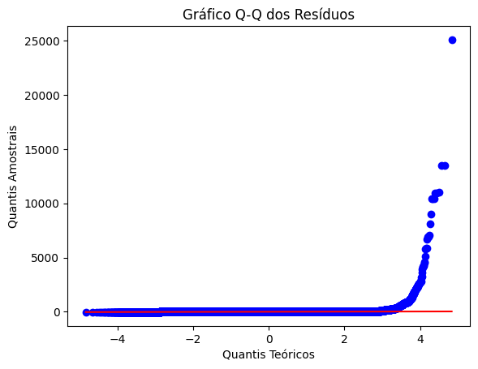

```python
# Plot do gráfico Q-Q dos resíduos dos preços

residuos_pri = model_pri.resid

stats.probplot(residuos_pri, dist="norm", plot=plt)
plt.title('Gráfico Q-Q dos Resíduos')
plt.xlabel('Quantis Teóricos')
plt.ylabel('Quantis Amostrais')
plt.show()
```

```python
#Shapiro-Wilk on residuals for Quantity

w, pvalue = stats.shapiro(model_qua.resid)
print('Statistics= %.3f, pvalue=%.3f' % (w, pvalue))
# interpret
alpha = 0.05
if pvalue > alpha:
	print('Resíduo com Distribuição Normal (Não rejeita H0)')
else:
	print('Diferente da Normal (rejeita H0)')
```

```
Statistics= 0.023, pvalue=0.000
Diferente da Normal (rejeita H0)
```

```python
# perform the Kolmogorov-Smirnov test on the residuals for Quantity
k_statistic, pvalue = stats.kstest(model_qua.resid, 'norm')

# print the results and interpret
alpha = 0.05
if pvalue > alpha:
    print('Resíduo com Distribuição Normal (Não rejeita H0)')
else:
    print('Diferente da Normal (rejeita H0)')

print('K-S Statistic= %.3f, pvalue=%.3f' % (k_statistic, pvalue))
```

```
Diferente da Normal (rejeita H0)
K-S Statistic= 0.702, pvalue=0.000
```

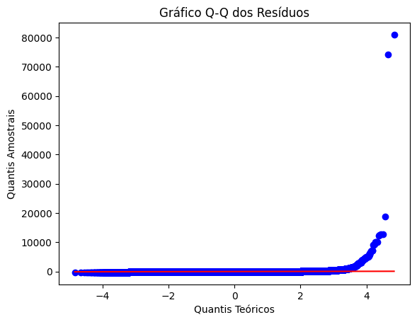

```python
# Plot do gráfico Q-Q dos resíduos das quantidades

residuos_qua = model_qua.resid

stats.probplot(residuos_qua, dist="norm", plot=plt)
plt.title('Gráfico Q-Q dos Resíduos')
plt.xlabel('Quantis Teóricos')
plt.ylabel('Quantis Amostrais')
plt.show()
```

Conforme com os dados do **P-value** obtidos, se observa, em ambos os Q-Q plot acima, a forte desigualdade das amostras alongo da linea reta (principalmente na parte final) o que significa que o modelo não esta seguindo uma distribução normal.

### Testes pra verificar homocedasticidade / heterocedasticidade, Levene

Vamos rodar o test de *Levene* para verificar a hipotese de homocedasticidade. O objetivo è testar se tem differencias de variancias.  
Se assume a seguinte hipotese $H_0$: a variancia entre os grupos è igual.  
Por tanto se *P-value > alpha* então a hipotese *$H_0$* não pode ser reijetada, em caso contrario se *P-value < alpha* terà variância diferente.

```python
# Test Levene for Price

from scipy.stats import levene

grouped_data_pri = tab_pri.groupby('variable')['value']

# Extract the values for each group
groups_pri = []
for group, values in grouped_data_pri:
    groups_pri.append(values.tolist())

w, pvalue = levene(*groups_pri)
print('Statistics= %.3f, pvalue=%.3f' % (w, pvalue))
# interpret
alpha = 0.05
if pvalue > alpha:
	print('Same Variance (Não rejeita H0)')
else:
	print('Different Variance (rejeita H0)')
```

```
Statistics= 12.402, pvalue=0.000
Different Variance (rejeita H0)
```

```python
# Teste di Levene for Quantity

from scipy.stats import levene

grouped_data_qua = tab_qua.groupby('variable')['value']

# Extract the values for each group
groups_qua = []
for group, values in grouped_data_qua:
    groups_qua.append(values.tolist())

w, pvalue = levene(*groups_qua)
print('Statistics= %.3f, pvalue=%.3f' % (w, pvalue))
# interpret
alpha = 0.05
if pvalue > alpha:
	print('Same Variance (Não rejeita H0)')
else:
	print('Different Variance (rejeita H0)')
```

```
Statistics= 192.499, pvalue=0.000
Different Variance (rejeita H0)
```

Conforme os resultados obtidos em ambos os testes acima, confirmamos a presença de heterocedasticidade pois **P-value** è menor de 0.05.

Diante de todos os dados obtidos, **por causa de falta de normalidade e presencia de heterocedasticidade** temos que reijetar o metodo ANOVA e optar por um modelo de test não parametrico para puder testar a hipotese $H_0$.

```
                                    ### questão b) ###
```

## Tests assumindo não Normalidade

Se assume que não há distribução de normalidade.  
Mesmo assumindo um modelo não parametrico queremos verificar se as medias dos grupos são diferentes o que era a hipotese nula *$H_0$* .

Para alcançar nosso objetivo executaremos o test de *Kruskal-Wallis* que executa a comparação entre as medias de forma global.

### Kruskal-Wallis Test

```python
# Price
#show_krus = []
# Assuming 'tab_qua' is a melted DataFrame with columns 'group' and 'value'
grouped_data_pri = tab_pri.groupby('variable')['value']

# Extract the values for each group
groups_pri = []
for group, values in grouped_data_pri:
    groups_pri.append(values.tolist())

stats, p = kruskal(*groups_pri)
print('Statistics= %.3f, p=%.3f' % (stats, p))
# interpret
alpha = 0.05
if p > alpha:
	print('Same distribution (Não rejeita H0)')
else:
	print('Different distribution (rejeita H0)')
```

```
Statistics= 2149.470, p=0.000
Different distribution (rejeita H0)
```

```python
# Quantity

# Assuming 'tab_qua' is a melted DataFrame with columns 'group' and 'value'
grouped_data_qua = tab_qua.groupby('variable')['value']

# Extract the values for each group
groups_qua = []
for group, values in grouped_data_qua:
    groups_qua.append(values.tolist())

stats, p = kruskal(*groups_qua)
print('Statistics= %.3f, p=%.3f' % (stats, p))
# interpret
alpha = 0.05
if p > alpha:
	print('Same distribution (Não rejeita H0)')
else:
	print('Different distribution (rejeita H0)')
```

```
Statistics= 52315.554, p=0.000
Different distribution (rejeita H0)
```

#### Conclusoes finais

Os resultados obtidos a partir da análise estatística fornecem informações valiosas sobre a comparação de preço e quantidade entre diferentes países.

Os testes iniciais de normalidade revelaram que os dados para as variáveis "Preço" e "Quantidade" não seguiam uma distribuição normal dentro de cada grupo de país. Isso indica que a suposição de normalidade necessária para a ANOVA pode não ser atendida neste caso.

O teste ANOVA subsequente foi realizado mesmo com a violação da suposição de normalidade. Os resultados da ANOVA indicaram que existem diferenças estatisticamente significativas tanto no preço quanto na quantidade entre os grupos de países.

Para investigar ainda mais essas diferenças, foi realizado o teste de Tukey para identificar diferenças específicas entre pares de grupos de países. O teste de Tukey revelou que certos grupos de países, como Hong Kong, Singapura e Noruega, apresentaram valores de preço significativamente diferentes em comparação com outros grupos. Da mesma forma, países como Austrália, Dinamarca, Japão, Holanda e Suécia exibiram diferenças significativas em termos de quantidade.

Para validar a suposição de normalidade, foram realizados testes adicionais, incluindo os testes de Shapiro-Wilk e Kolmogorov-Smirnov. Ambos os testes confirmaram o rejeição da suposição de normalidade, corroborando ainda mais as descobertas iniciais.

Além disso, o teste de Levene indicou a presença de heterocedasticidade, sugerindo que a variância das variáveis entre os grupos de países não é consistente.

Considerando as violações das suposições de normalidade e homocedasticidade, o teste não paramétrico de Kruskal-Wallis foi realizado como uma alternativa à ANOVA. Os resultados do teste de Kruskal-Wallis corroboraram as descobertas da ANOVA, indicando que existem diferenças significativas no preço e na quantidade entre os grupos de países.

Em conclusão, com base na análise realizada, pode-se inferir que existem variações significativas tanto no preço quanto na quantidade entre os diferentes grupos de países. No entanto, é importante observar que a natureza específica dessas diferenças e os fatores que contribuem para elas exigiriam investigações adicionais, incluindo uma análise mais aprofundada dos dados e consideração de variáveis adicionais.

Essas descobertas podem ser valiosas para entender a dinâmica de mercado, o comportamento do consumidor e os fatores econômicos que influenciam as variações de preço e quantidade entre os diferentes países. Elas podem fornecer insights para empresas, formuladores de políticas e pesquisadores na tomada de decisões e estratégias informadas relacionadas a precificação, entrada no mercado e comércio internacional.